# Multiple Linear Regression on Customer Data

Insofe Lab Session

July 02 , 2017

```r
# Go through the data and understand the attributes to get the info of the variables.
```

Write a code to clear the environment if needed

```r
rm(list = ls(all = TRUE))
```

Write a code to set the working directory.

```r
setwd("C:/Users/Thomas/Desktop/20170702_Batch30_CSE7302c_CustomerData_Assignment")
```

Think and load the libraries as and when required in this place only as best practice

```r
library(vegan)
```

```r
library(corrplot)
library(car)
library(DMwR)
library(MASS)
library(e1071)
```

Write a code to read the csv file as “data” as per required

```r
customer.data = read.csv(file = "20170702_Batch30_CSE7302c_CustomerData_Assignment.csv", header = TRUE)
```

Write a code to know the names of the attributes

```r
names(customer.data)
```

```
##  [1] "CustomerID"                   "City"
##  [3] "NoOfChildren"                 "MinAgeOfChild"
##  [5] "MaxAgeOfChild"                "Tenure"
##  [7] "FrquncyOfPurchase"            "NoOfUnitsPurchased"
##  [9] "FrequencyOFPlay"              "NoOfGamesPlayed"
## [11] "NoOfGamesBought"              "FavoriteChannelOfTransaction"
## [13] "FavoriteGame"                 "TotalRevenueGenerated"
```

Write a code to find the dimensions of the data

```r
dim(customer.data)
```

```
## [1] 3209   14
```

Write a code to see the head and tail of the dataset atleast 10rows

```r
head(x = customer.data, n = 10L)
```

```
##    CustomerID City NoOfChildren MinAgeOfChild MaxAgeOfChild Tenure
## 1        1001    1            2             3             8    210
## 2        1002    1            2             3             6    442
## 3        1003    1            4             3             5    424
## 4        1004    1            1             6             6    261
## 5        1005    1            3             6             9    422
## 6        1006    1            2             3             4    378
## 7        1007    1            3             8            12    369
## 8        1008    1            2             6             8    404
## 9        1009    1            4             6             9    420
## 10       1010    2            3             5             6    333
##    FrquncyOfPurchase NoOfUnitsPurchased FrequencyOFPlay NoOfGamesPlayed
## 1                 11                 11            2344             108
## 2                 20                 20             245              22
## 3                 18                 18            1059             130
```

[output cut: 29 more lines]

```r
tail(x = customer.data, n = 10L)
```

```
##      CustomerID City NoOfChildren MinAgeOfChild MaxAgeOfChild Tenure
## 3200       4200    1            1             6             6    352
## 3201       4201    1            2             7             8    313
## 3202       4202    1            3             2             6    424
## 3203       4203    1            2             5             7    424
## 3204       4204    1            1             4             4    431
## 3205       4205    1            2             4             6    365
## 3206       4206    1            2             2             5    348
## 3207       4207    1            2             5             7    341
## 3208       4208    1            2             6             7    368
## 3209       4209    1            3             2             6    389
##      FrquncyOfPurchase NoOfUnitsPurchased FrequencyOFPlay NoOfGamesPlayed
## 3200                27                 24            2042             194
## 3201                15                 15             952             113
## 3202                20                 12            2038             177
```

[output cut: 29 more lines]

Write a code to see the data types of the attributes

```r
str(customer.data)
```

```
## 'data.frame':    3209 obs. of  14 variables:
##  $ CustomerID                  : int  1001 1002 1003 1004 1005 1006 1007 1008 1009 1010 ...
##  $ City                        : int  1 1 1 1 1 1 1 1 1 2 ...
##  $ NoOfChildren                : int  2 2 4 1 3 2 3 2 4 3 ...
##  $ MinAgeOfChild               : int  3 3 3 6 6 3 8 6 6 5 ...
##  $ MaxAgeOfChild               : int  8 6 5 6 9 4 12 8 9 6 ...
##  $ Tenure                      : int  210 442 424 261 422 378 369 404 420 333 ...
##  $ FrquncyOfPurchase           : int  11 20 18 11 44 16 25 13 20 15 ...
##  $ NoOfUnitsPurchased          : int  11 20 18 9 31 16 15 12 16 15 ...
##  $ FrequencyOFPlay             : int  2344 245 1059 365 1066 228 75 1488 2743 1967 ...
##  $ NoOfGamesPlayed             : int  108 22 130 34 102 12 2 118 163 56 ...
##  $ NoOfGamesBought             : int  10 7 18 11 44 16 25 13 16 15 ...
##  $ FavoriteChannelOfTransaction: Factor w/ 2 levels "Favorite","Uniform": 2 1 1 1 2 1 1 1 2 1 ...
##  $ FavoriteGame                : Factor w/ 3 levels "Favorite","NONE",..: 3 3 3 3 3 1 1 3 3 3 ...
##  $ TotalRevenueGenerated       : num  108 382 135 125 335 ...
```

Write a code to remove the unuseful variables and store the data

```r
customer.data.withoutCustomerId = customer.data
customer.data.withoutCustomerId$CustomerID = NULL
```

Write a code to observe the variables and convert them into the required formats

```r
summary(customer.data.withoutCustomerId)
```

```
##       City        NoOfChildren    MinAgeOfChild     MaxAgeOfChild
##  Min.   :1.000   Min.   : 1.000   Min.   :  0.000   Min.   :  3.000
##  1st Qu.:1.000   1st Qu.: 1.000   1st Qu.:  4.000   1st Qu.:  6.000
##  Median :1.000   Median : 2.000   Median :  5.000   Median :  7.000
##  Mean   :1.114   Mean   : 2.128   Mean   :  4.961   Mean   :  7.991
##  3rd Qu.:1.000   3rd Qu.: 3.000   3rd Qu.:  6.000   3rd Qu.:  8.000
##  Max.   :2.000   Max.   :11.000   Max.   :113.000   Max.   :113.000
##      Tenure      FrquncyOfPurchase NoOfUnitsPurchased FrequencyOFPlay
##  Min.   :100.0   Min.   :  1.00    Min.   :  1.00     Min.   :    0
##  1st Qu.:301.0   1st Qu.: 11.00    1st Qu.: 10.00     1st Qu.:  446
##  Median :368.0   Median : 14.00    Median : 13.00     Median : 1029
##  Mean   :347.5   Mean   : 16.27    Mean   : 14.68     Mean   : 1568
##  3rd Qu.:417.0   3rd Qu.: 19.00    3rd Qu.: 17.00     3rd Qu.: 2029
##  Max.   :472.0   Max.   :119.00    Max.   :112.00     Max.   :27829
##  NoOfGamesPlayed   NoOfGamesBought  FavoriteChannelOfTransaction
##  Min.   :   0.00   Min.   :  0.00   Favorite:2637
##  1st Qu.:  37.00   1st Qu.: 10.00   Uniform : 572
##  Median :  70.00   Median : 14.00
##  Mean   :  93.63   Mean   : 14.76
##  3rd Qu.: 119.00   3rd Qu.: 19.00
##  Max.   :1166.00   Max.   :115.00
##    FavoriteGame  TotalRevenueGenerated
##  Favorite: 126   Min.   :100.0
##  NONE    :  30   1st Qu.:116.6
##  Uniform :3053   Median :142.4
##                  Mean   :168.5
##                  3rd Qu.:191.2
##                  Max.   :990.6
```

```r
# Code to remove the outliers (rows)
customer.data.withoutCustomerId = customer.data.withoutCustomerId[(customer.data.withoutCustomerId$FrequencyOFPlay < 10000),]
customer.data.withoutCustomerId = customer.data.withoutCustomerId[(customer.data.withoutCustomerId$NoOfChildren <= 10),]
customer.data.withoutCustomerId = customer.data.withoutCustomerId[(customer.data.withoutCustomerId$MinAgeOfChild < 15),]
customer.data.withoutCustomerId = customer.data.withoutCustomerId[customer.data.withoutCustomerId$NoOfGamesBought < 100,]
customer.data.withoutCustomerId = customer.data.withoutCustomerId[customer.data.withoutCustomerId$NoOfGamesPlayed < 500,]
customer.data.withoutCustomerId = customer.data.withoutCustomerId[customer.data.withoutCustomerId$NoOfUnitsPurchased < 50,]
customer.data.withoutCustomerId = customer.data.withoutCustomerId[customer.data.withoutCustomerId$FrquncyOfPurchase < 50,]

#Removing some wrong values in the data and applying KNNImputation to these values
# Age of children can never be greater than 100
customer.data.withoutCustomerId[customer.data.withoutCustomerId$MinAgeOfChild > 100,"MinAgeOfChild"] = NA
customer.data.withoutCustomerId[customer.data.withoutCustomerId$MaxAgeOfChild > 100,"MaxAgeOfChild"] = NA
# Library DMwR
customer.data.withoutCustomerId= knnImputation(data = customer.data.withoutCustomerId, k = 5)

summary(customer.data.withoutCustomerId)
```

```
##       City        NoOfChildren   MinAgeOfChild   MaxAgeOfChild
##  Min.   :1.000   Min.   :1.000   Min.   : 0.00   Min.   : 3.000
##  1st Qu.:1.000   1st Qu.:1.000   1st Qu.: 4.00   1st Qu.: 6.000
##  Median :1.000   Median :2.000   Median : 5.00   Median : 7.000
##  Mean   :1.114   Mean   :2.117   Mean   : 4.85   Mean   : 7.324
##  3rd Qu.:1.000   3rd Qu.:3.000   3rd Qu.: 6.00   3rd Qu.: 8.000
##  Max.   :2.000   Max.   :9.000   Max.   :12.00   Max.   :23.000
##      Tenure      FrquncyOfPurchase NoOfUnitsPurchased FrequencyOFPlay
##  Min.   :100.0   Min.   : 1.00     Min.   : 1.0       Min.   :   0
##  1st Qu.:299.5   1st Qu.:11.00     1st Qu.:10.0       1st Qu.: 444
##  Median :367.0   Median :14.00     Median :13.0       Median :1013
##  Mean   :346.6   Mean   :15.85     Mean   :14.3       Mean   :1468
##  3rd Qu.:416.0   3rd Qu.:19.00     3rd Qu.:17.0       3rd Qu.:1942
##  Max.   :472.0   Max.   :49.00     Max.   :47.0       Max.   :9697
##  NoOfGamesPlayed  NoOfGamesBought FavoriteChannelOfTransaction
##  Min.   :  0.00   Min.   : 0.00   Favorite:2584
##  1st Qu.: 37.00   1st Qu.:10.00   Uniform : 567
##  Median : 69.00   Median :13.00
##  Mean   : 88.78   Mean   :14.36
##  3rd Qu.:117.00   3rd Qu.:18.00
##  Max.   :486.00   Max.   :49.00
##    FavoriteGame  TotalRevenueGenerated
##  Favorite: 126   Min.   :100.0
##  NONE    :  30   1st Qu.:115.9
##  Uniform :2995   Median :140.5
##                  Mean   :164.5
##                  3rd Qu.:189.3
##                  Max.   :771.0
```

```r
# To convert the vaiables into Factors
categorical.attributes = c("City", "FavoriteChannelOfTransaction", "FavoriteGame")
customer.data.withoutCustomerId[,categorical.attributes] = data.frame(apply(customer.data.withoutCustomerId[,categorical.attributes],2,function(x) as.factor(as.character(x))))
```

Check the changes again using str() command

```r
str(customer.data.withoutCustomerId)
```

```
## 'data.frame':    3151 obs. of  13 variables:
##  $ City                        : Factor w/ 2 levels "1","2": 1 1 1 1 1 1 1 1 1 2 ...
##  $ NoOfChildren                : int  2 2 4 1 3 2 3 2 4 3 ...
##  $ MinAgeOfChild               : int  3 3 3 6 6 3 8 6 6 5 ...
##  $ MaxAgeOfChild               : num  8 6 5 6 9 4 12 8 9 6 ...
##  $ Tenure                      : int  210 442 424 261 422 378 369 404 420 333 ...
##  $ FrquncyOfPurchase           : int  11 20 18 11 44 16 25 13 20 15 ...
##  $ NoOfUnitsPurchased          : int  11 20 18 9 31 16 15 12 16 15 ...
##  $ FrequencyOFPlay             : int  2344 245 1059 365 1066 228 75 1488 2743 1967 ...
##  $ NoOfGamesPlayed             : int  108 22 130 34 102 12 2 118 163 56 ...
##  $ NoOfGamesBought             : int  10 7 18 11 44 16 25 13 16 15 ...
##  $ FavoriteChannelOfTransaction: Factor w/ 2 levels "Favorite","Uniform": 2 1 1 1 2 1 1 1 2 1 ...
##  $ FavoriteGame                : Factor w/ 3 levels "Favorite","NONE",..: 3 3 3 3 3 1 1 3 3 3 ...
##  $ TotalRevenueGenerated       : num  108 382 135 125 335 ...
```

Write a Code to seperate the target

```r
TotalRevenueGenerated = customer.data.withoutCustomerId$TotalRevenueGenerated
```

Write a code to get the numerical attributes out and store them as data_num

```r
numerical.attributes = c("NoOfChildren", "MinAgeOfChild", "MaxAgeOfChild", "Tenure", "NoOfUnitsPurchased","FrquncyOfPurchase", "FrequencyOFPlay","NoOfGamesPlayed", "NoOfGamesBought")
data_num = customer.data.withoutCustomerId[, numerical.attributes]
```

Write a code for Normalizing the data_num

```r
# Library vegan
normalized.data_num = decostand(data_num, "normalize", MARGIN = 2)
```

Write a code to observe the correlation between the attributes

```r
r = cor(normalized.data_num)
r
```

```
##                    NoOfChildren MinAgeOfChild MaxAgeOfChild      Tenure
## NoOfChildren         1.00000000   -0.35209070   0.470088335  0.07835039
## MinAgeOfChild       -0.35209070    1.00000000   0.245618640 -0.16482138
## MaxAgeOfChild        0.47008834    0.24561864   1.000000000 -0.04353032
## Tenure               0.07835039   -0.16482138  -0.043530321  1.00000000
## NoOfUnitsPurchased   0.12486566   -0.10529212  -0.006674528  0.19250739
## FrquncyOfPurchase    0.12385047   -0.11134932   0.004613855  0.18763815
## FrequencyOFPlay      0.15296633   -0.10882065   0.001221403  0.25176963
## NoOfGamesPlayed      0.20803313   -0.11844208   0.037558498  0.28148710
## NoOfGamesBought      0.11414624   -0.09336059  -0.006211917  0.18123283
##                    NoOfUnitsPurchased FrquncyOfPurchase FrequencyOFPlay
## NoOfChildren              0.124865657       0.123850472     0.152966332
## MinAgeOfChild            -0.105292123      -0.111349317    -0.108820654
## MaxAgeOfChild            -0.006674528       0.004613855     0.001221403
## Tenure                    0.192507388       0.187638146     0.251769629
## NoOfUnitsPurchased        1.000000000       0.930601180     0.273227042
## FrquncyOfPurchase         0.930601180       1.000000000     0.235297288
## FrequencyOFPlay           0.273227042       0.235297288     1.000000000
## NoOfGamesPlayed           0.405926095       0.365736690     0.749421207
## NoOfGamesBought           0.853619169       0.936990990     0.252180001
##                    NoOfGamesPlayed NoOfGamesBought
## NoOfChildren             0.2080331     0.114146237
## MinAgeOfChild           -0.1184421    -0.093360593
## MaxAgeOfChild            0.0375585    -0.006211917
## Tenure                   0.2814871     0.181232834
## NoOfUnitsPurchased       0.4059261     0.853619169
## FrquncyOfPurchase        0.3657367     0.936990990
## FrequencyOFPlay          0.7494212     0.252180001
## NoOfGamesPlayed          1.0000000     0.374659305
## NoOfGamesBought          0.3746593     1.000000000
```

Write a code to plot the corrplot of correlation between the attributes

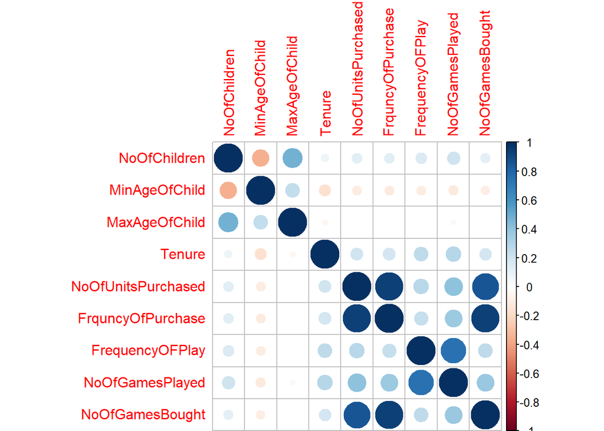

```r
# Library corrplot
corrplot(r)
```

Write a code to seperate the categorical attributes

```r
data_cat = customer.data.withoutCustomerId[, categorical.attributes]
```

Write a code to combine the numerical,categorical data along with the target

```r
customer.data.withoutCustomerId = cbind(normalized.data_num,data_cat, TotalRevenueGenerated)
```

Write a code to set the seed and comment why it is used.

```r
# Setting the seed to make sure that the same set of rows are taken each time when we randomly select the training and test data.
set.seed(1234)
```

Write a code to get the train rows using sample

```r
train.rows = sample(x = 1:nrow(customer.data.withoutCustomerId), size = 0.7*nrow(customer.data.withoutCustomerId))
```

Write a code to get the train and test

```r
train.data = customer.data.withoutCustomerId[train.rows, ]
test.data = customer.data.withoutCustomerId[-train.rows, ]
```

Write a code to just plot the grahs between attributes and targets

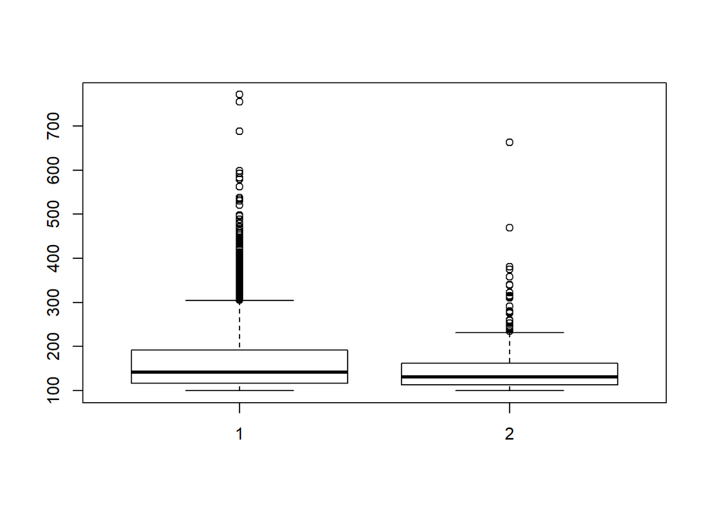

```r
plot(customer.data.withoutCustomerId$City, customer.data.withoutCustomerId$TotalRevenueGenerated)
```

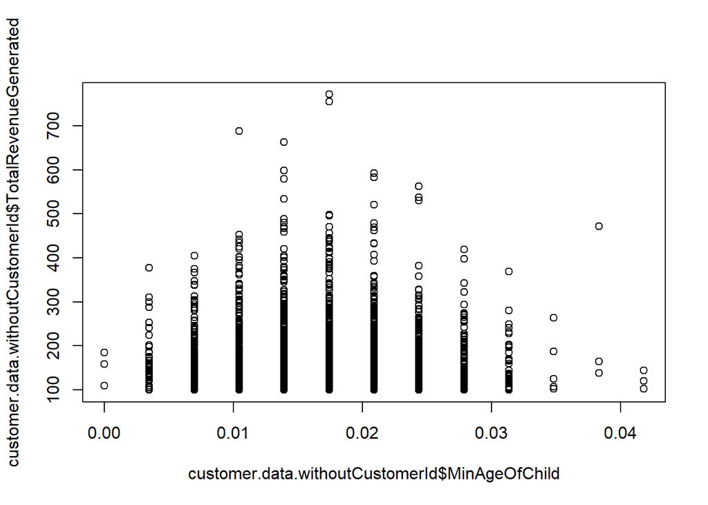

```r
plot(customer.data.withoutCustomerId$MinAgeOfChild, customer.data.withoutCustomerId$TotalRevenueGenerated)
```

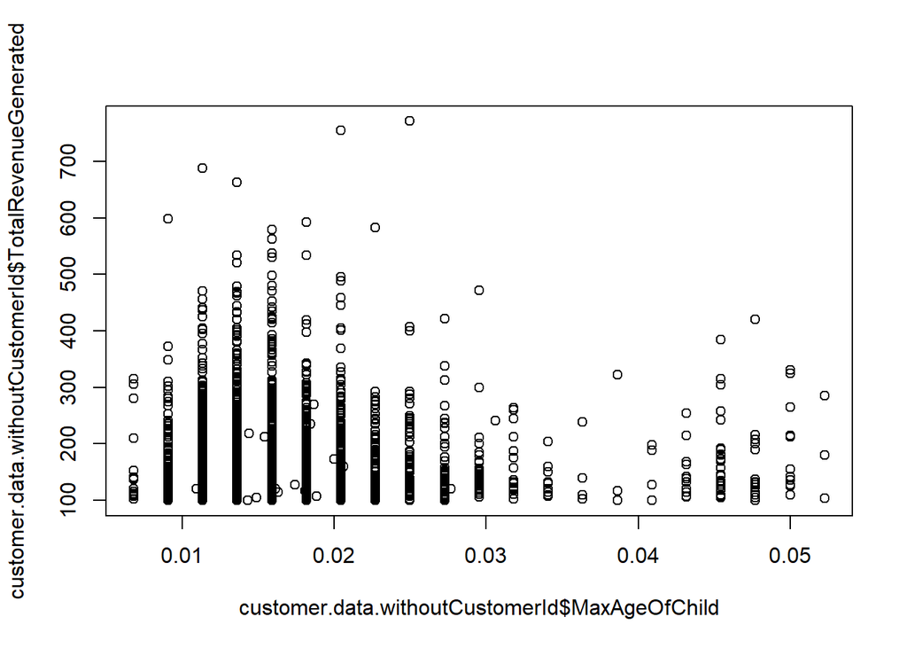

```r
plot(customer.data.withoutCustomerId$MaxAgeOfChild, customer.data.withoutCustomerId$TotalRevenueGenerated)
```

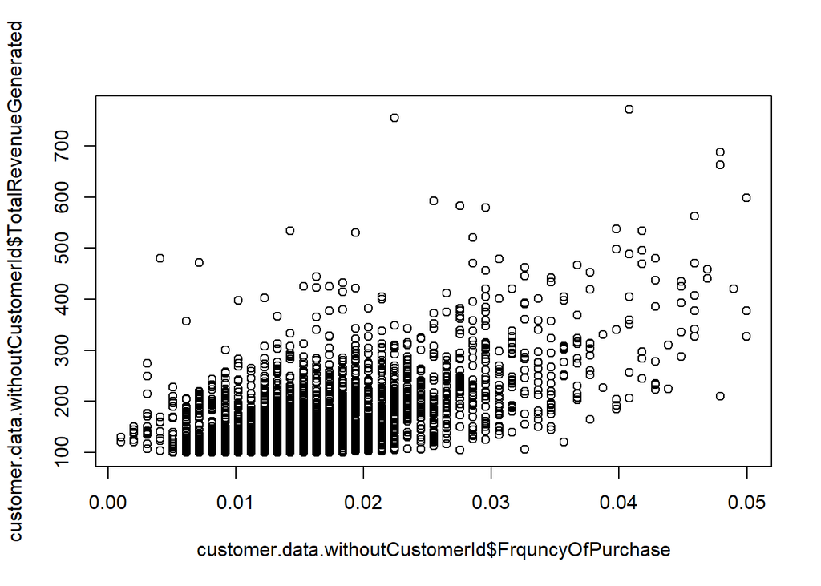

```r
plot(customer.data.withoutCustomerId$FrquncyOfPurchase, customer.data.withoutCustomerId$TotalRevenueGenerated)
```

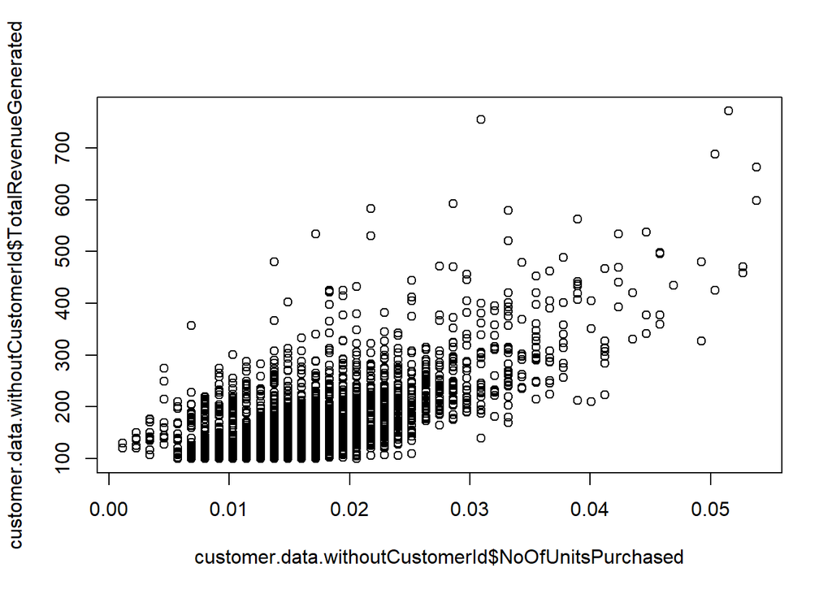

```r
plot(customer.data.withoutCustomerId$NoOfUnitsPurchased, customer.data.withoutCustomerId$TotalRevenueGenerated)
```

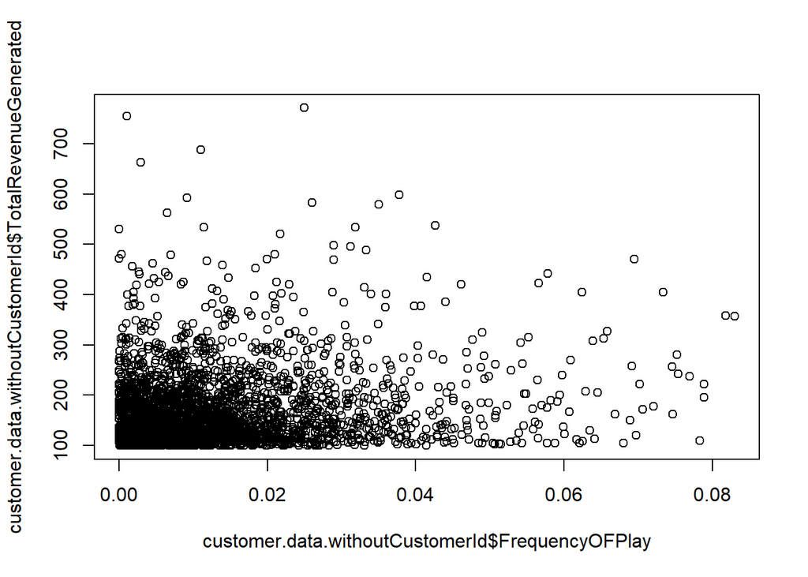

```r
plot(customer.data.withoutCustomerId$FrequencyOFPlay, customer.data.withoutCustomerId$TotalRevenueGenerated)
```

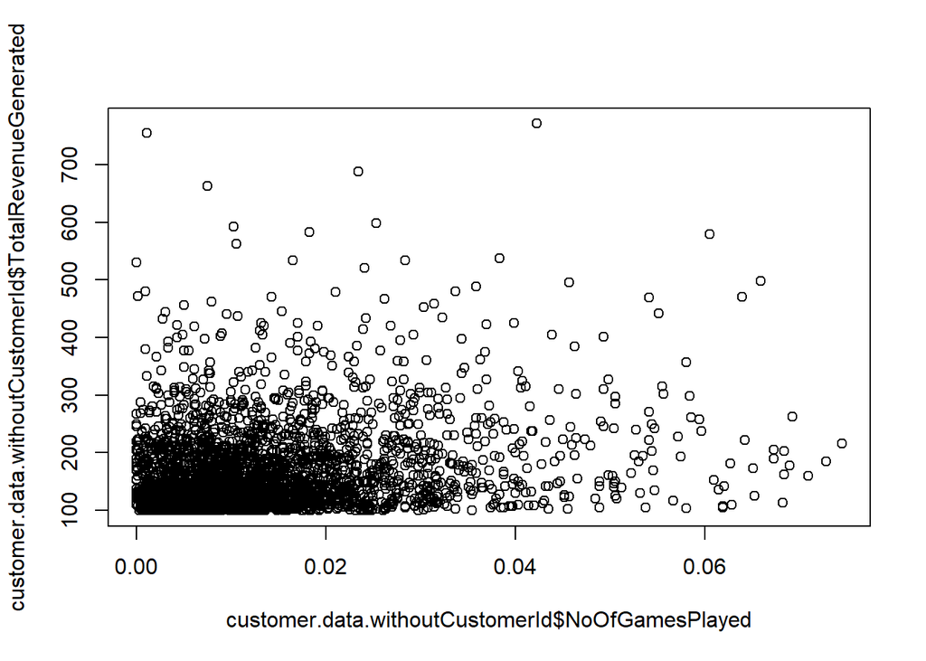

```r
plot(customer.data.withoutCustomerId$NoOfGamesPlayed, customer.data.withoutCustomerId$TotalRevenueGenerated)
```

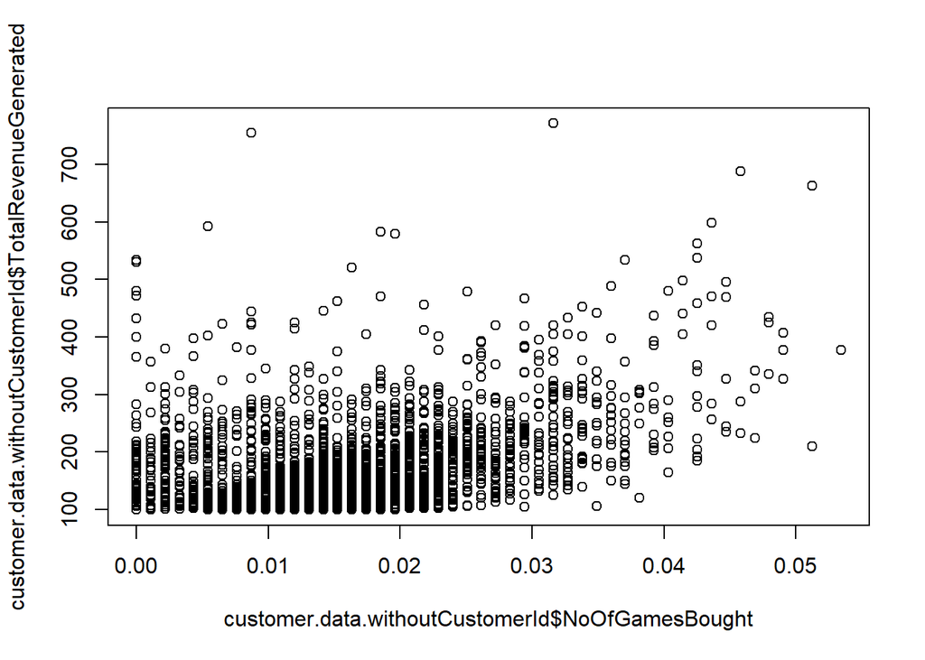

```r
plot(customer.data.withoutCustomerId$NoOfGamesBought, customer.data.withoutCustomerId$TotalRevenueGenerated)
```

Write a code to form a linear regression model

```r
lm.model.ordinary = lm(TotalRevenueGenerated ~ City + NoOfChildren + MinAgeOfChild + MaxAgeOfChild + NoOfUnitsPurchased + FrquncyOfPurchase + FrequencyOFPlay + (NoOfGamesPlayed * NoOfGamesBought) + FavoriteChannelOfTransaction + FavoriteGame , data = train.data)
```

Write a code to plot the model

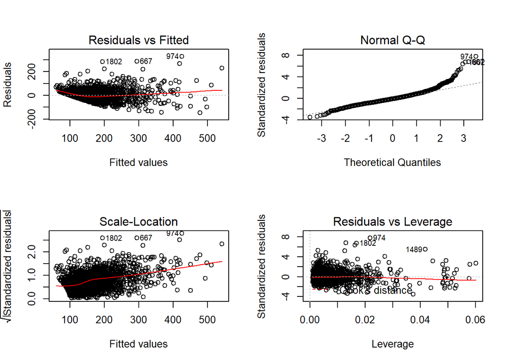

```r
par(mfrow = c(2,2))
plot(lm.model.ordinary)
```

Write a code to check the summary of the model

```r
summary(lm.model.ordinary)
```

```
##
## Call:
## lm(formula = TotalRevenueGenerated ~ City + NoOfChildren + MinAgeOfChild +
##     MaxAgeOfChild + NoOfUnitsPurchased + FrquncyOfPurchase +
##     FrequencyOFPlay + (NoOfGamesPlayed * NoOfGamesBought) + FavoriteChannelOfTransaction +
##     FavoriteGame, data = train.data)
##
## Residuals:
##     Min      1Q  Median      3Q     Max
## -147.37  -26.31   -3.62   20.56  328.70
##
## Coefficients:
##                                       Estimate Std. Error t value Pr(>|t|)
## (Intercept)                             34.013      6.554   5.190 2.30e-07
## City2                                   10.905      2.974   3.667 0.000251
## NoOfChildren                           565.054    162.598   3.475 0.000520
## MinAgeOfChild                          941.825    197.981   4.757 2.09e-06
## MaxAgeOfChild                         -316.603    188.782  -1.677 0.093669
## NoOfUnitsPurchased                    7104.293    378.524  18.768  < 2e-16
## FrquncyOfPurchase                    10755.620    525.659  20.461  < 2e-16
## FrequencyOFPlay                        379.183    109.788   3.454 0.000563
## NoOfGamesPlayed                      -1191.943    209.805  -5.681 1.52e-08
## NoOfGamesBought                     -11098.599    329.423 -33.691  < 2e-16
## FavoriteChannelOfTransactionUniform    -12.976      2.524  -5.140 2.99e-07
## FavoriteGameNONE                        -1.579     10.378  -0.152 0.879048
## FavoriteGameUniform                     -2.871      4.600  -0.624 0.532576
## NoOfGamesPlayed:NoOfGamesBought      41318.930   8357.898   4.944 8.25e-07
##
## (Intercept)                         ***
## City2                               ***
## NoOfChildren                        ***
## MinAgeOfChild                       ***
## MaxAgeOfChild                       .
## NoOfUnitsPurchased                  ***
## FrquncyOfPurchase                   ***
## FrequencyOFPlay                     ***
## NoOfGamesPlayed                     ***
## NoOfGamesBought                     ***
## FavoriteChannelOfTransactionUniform ***
## FavoriteGameNONE
## FavoriteGameUniform
## NoOfGamesPlayed:NoOfGamesBought     ***
## ---
## Signif. codes:  0 '***' 0.001 '**' 0.01 '*' 0.05 '.' 0.1 ' ' 1
##
## Residual standard error: 42.63 on 2191 degrees of freedom
## Multiple R-squared:  0.6604, Adjusted R-squared:  0.6584
## F-statistic: 327.8 on 13 and 2191 DF,  p-value: < 2.2e-16
```

Write a code to predict the value of the target on the linear model

```r
data.predict = predict(lm.model.ordinary, test.data[, !(names(test.data) %in% c("TotalRevenueGenerated"))])
```

Write a code to use stepAIC

```r
lm.model.stepAIC = stepAIC(lm.model.ordinary, direction = "both")
```

```
## Start:  AIC=16563.15
## TotalRevenueGenerated ~ City + NoOfChildren + MinAgeOfChild +
##     MaxAgeOfChild + NoOfUnitsPurchased + FrquncyOfPurchase +
##     FrequencyOFPlay + (NoOfGamesPlayed * NoOfGamesBought) + FavoriteChannelOfTransaction +
##     FavoriteGame
##
##                                   Df Sum of Sq     RSS   AIC
## - FavoriteGame                     2       720 3983200 16560
## <none>                                         3982480 16563
## - MaxAgeOfChild                    1      5112 3987593 16564
## - FrequencyOFPlay                  1     21682 4004163 16573
## - NoOfChildren                     1     21951 4004432 16573
## - City                             1     24439 4006920 16575
## - MinAgeOfChild                    1     41134 4023615 16584
## - NoOfGamesPlayed:NoOfGamesBought  1     44424 4026904 16586
## - FavoriteChannelOfTransaction     1     48027 4030508 16588
## - NoOfUnitsPurchased               1    640273 4622754 16890
## - FrquncyOfPurchase                1    760982 4743463 16947
##
## Step:  AIC=16559.54
## TotalRevenueGenerated ~ City + NoOfChildren + MinAgeOfChild +
##     MaxAgeOfChild + NoOfUnitsPurchased + FrquncyOfPurchase +
##     FrequencyOFPlay + NoOfGamesPlayed + NoOfGamesBought + FavoriteChannelOfTransaction +
##     NoOfGamesPlayed:NoOfGamesBought
##
##                                   Df Sum of Sq     RSS   AIC
## <none>                                         3983200 16560
## - MaxAgeOfChild                    1      5190 3988390 16560
## + FavoriteGame                     2       720 3982480 16563
## - FrequencyOFPlay                  1     21534 4004734 16569
## - NoOfChildren                     1     22052 4005252 16570
## - City                             1     24444 4007644 16571
## - MinAgeOfChild                    1     41586 4024786 16580
## - FavoriteChannelOfTransaction     1     48180 4031380 16584
## - NoOfGamesPlayed:NoOfGamesBought  1     48429 4031629 16584
## - NoOfUnitsPurchased               1    640278 4623478 16886
## - FrquncyOfPurchase                1    769554 4752754 16947
```

Write a code to predict it on stepAIC

```r
data.predict.stepAIC = predict(lm.model.stepAIC, test.data[, !(names(test.data) %in% c("TotalRevenueGenerated"))])
```

Write a code to check the multicollinearity in the lm model

```r
vif(lm.model.ordinary)
```

```
##                                      GVIF Df GVIF^(1/(2*Df))
## City                             1.082325  1        1.040348
## NoOfChildren                     1.944582  1        1.394483
## MinAgeOfChild                    1.566044  1        1.251417
## MaxAgeOfChild                    1.755946  1        1.325121
## NoOfUnitsPurchased               8.800694  1        2.966596
## FrquncyOfPurchase               19.299691  1        4.393141
## FrequencyOFPlay                  2.277993  1        1.509302
## NoOfGamesPlayed                  7.043828  1        2.654021
## NoOfGamesBought                  9.772635  1        3.126121
## FavoriteChannelOfTransaction     1.111848  1        1.054442
## FavoriteGame                     1.155144  2        1.036714
## NoOfGamesPlayed:NoOfGamesBought  8.321342  1        2.884674
```

Write a code to check the plots of the models

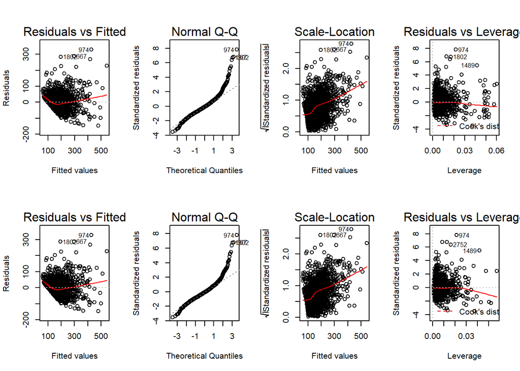

```r
par(mfrow = c(2,4))
plot(lm.model.ordinary)
plot(lm.model.stepAIC)
```

Write a code to check the multicollinearity problem

```r
vif(lm.model.stepAIC)
```

```
##                            City                    NoOfChildren
##                        1.082097                        1.943988
##                   MinAgeOfChild                   MaxAgeOfChild
##                        1.562290                        1.753976
##              NoOfUnitsPurchased               FrquncyOfPurchase
##                        8.786162                       19.139888
##                 FrequencyOFPlay                 NoOfGamesPlayed
##                        2.277079                        6.717575
##                 NoOfGamesBought    FavoriteChannelOfTransaction
##                        9.326273                        1.111221
## NoOfGamesPlayed:NoOfGamesBought
##                        7.952508
```

Write a code to evaluate the error in the prediction of AIC

```r
regr.eval(test.data$TotalRevenueGenerated, data.predict.stepAIC)
```

```
##          mae          mse         rmse         mape
##   29.0679067 1593.4304771   39.9177965    0.1817721
```

Write a code to evaluate the error on the prediction of Linear Regression

```r
regr.eval(test.data$TotalRevenueGenerated, data.predict)
```

```
##          mae          mse         rmse         mape
##   29.0527323 1590.8979757   39.8860624    0.1816509
```